# Car Price Prediction with Machine Learning

**Objective:** predict the resale (selling) price of used cars from their features, and understand what actually drives price — to support real-world use cases like used-car marketplace pricing tools, trade-in valuation, and dealer inventory pricing.

**Dataset:** `car_data.csv` — 301 used-car listings with:

- `Car_Name` — model name (e.g. "city", "fortuner")
- `Year` — year of manufacture
- `Selling_Price` — price the car is being sold for now, in **lakhs INR** (target variable)
- `Present_Price` — current ex-showroom price of that model when new, in lakhs INR
- `Driven_kms` — total kilometers driven (mileage)
- `Fuel_Type` — Petrol / Diesel / CNG
- `Selling_type` — Dealer / Individual
- `Transmission` — Manual / Automatic
- `Owner` — number of previous owners

**Note on "brand goodwill":** the raw data doesn't include a separate manufacturer/brand column — only model names. We engineer a **brand proxy** from the first word of `Car_Name` (e.g. "corolla altis" -> "corolla") as a stand-in for brand/model identity and reputation, and treat `Present_Price` as the primary quantitative signal of brand+model market value ("goodwill"), since it already reflects how the market prices that make/model when new.

```python
import pandas as pd
import numpy as np
import matplotlib.pyplot as plt

from sklearn.model_selection import train_test_split, cross_val_score, KFold
from sklearn.compose import ColumnTransformer
from sklearn.pipeline import Pipeline
from sklearn.preprocessing import OneHotEncoder
from sklearn.linear_model import LinearRegression, Ridge
from sklearn.ensemble import RandomForestRegressor, GradientBoostingRegressor
from sklearn.metrics import r2_score, mean_squared_error, mean_absolute_error

pd.set_option('display.width', 140)
plt.rcParams.update({
    'figure.facecolor': 'white', 'axes.facecolor': 'white', 'font.size': 11,
    'axes.spines.top': False, 'axes.spines.right': False,
    'axes.grid': True, 'grid.alpha': 0.25,
})

C_MAIN, C_ALT, C_ACCENT, C_WARN = '#1f77b4', '#2ca02c', '#ff7f0e', '#d62728'
```

## 1. Load & Inspect the Data

```python
df_raw = pd.read_csv('car_data.csv')
print('Raw shape:', df_raw.shape)
df_raw.head()
```

```
Raw shape: (301, 9)
```

|  | Car_Name | Year | Selling_Price | Present_Price | Driven_kms | Fuel_Type | Selling_type | Transmission | Owner |
| --- | --- | --- | --- | --- | --- | --- | --- | --- | --- |
| 0 | ritz | 2014 | 3.35 | 5.59 | 27000 | Petrol | Dealer | Manual | 0 |
| 1 | sx4 | 2013 | 4.75 | 9.54 | 43000 | Diesel | Dealer | Manual | 0 |
| 2 | ciaz | 2017 | 7.25 | 9.85 | 6900 | Petrol | Dealer | Manual | 0 |
| 3 | wagon r | 2011 | 2.85 | 4.15 | 5200 | Petrol | Dealer | Manual | 0 |
| 4 | swift | 2014 | 4.60 | 6.87 | 42450 | Diesel | Dealer | Manual | 0 |

```python
print('Nulls:\n', df_raw.isnull().sum())
print('\nDuplicate rows:', df_raw.duplicated().sum())
print('\nDtypes:\n', df_raw.dtypes)
print('\nUnique cars:', df_raw['Car_Name'].nunique(), '| Year range:', df_raw['Year'].min(), '-', df_raw['Year'].max())
print('Fuel_Type:', df_raw['Fuel_Type'].unique().tolist())
print('Selling_type:', df_raw['Selling_type'].unique().tolist())
print('Transmission:', df_raw['Transmission'].unique().tolist())
print('Owner values:', sorted(df_raw['Owner'].unique().tolist()))
```

```
Nulls:
 Car_Name         0
Year             0
Selling_Price    0
Present_Price    0
Driven_kms       0
Fuel_Type        0
Selling_type     0
Transmission     0
Owner            0
dtype: int64

Duplicate rows: 2

Dtypes:
 Car_Name             str
Year               int64
Selling_Price    float64
Present_Price    float64
Driven_kms         int64
Fuel_Type            str
Selling_type         str
Transmission         str
Owner              int64
dtype: object

Unique cars: 98 | Year range: 2003 - 2018
Fuel_Type: ['Petrol', 'Diesel', 'CNG']
Selling_type: ['Dealer', 'Individual']
Transmission: ['Manual', 'Automatic']
Owner values: [0, 1, 3]
```

## 2. Data Cleaning

- No missing values.
- **2 exact duplicate rows** found (same car listed twice) — dropped.
- All categorical values are already clean/consistent (no typos or inconsistent casing to fix).

```python
df = df_raw.drop_duplicates().reset_index(drop=True)
print('Shape after removing duplicates:', df.shape)
```

```
Shape after removing duplicates: (299, 9)
```

## 3. Feature Engineering

```python
# --- Car age: more useful for pricing than raw manufacture year ---
CURRENT_YEAR = 2020  # dataset was collected around 2020
df['Car_Age'] = CURRENT_YEAR - df['Year']

# --- Brand proxy (goodwill) from the model name, grouping rare ones into 'Other' ---
df['Brand'] = df['Car_Name'].str.split().str[0].str.lower()
brand_counts = df['Brand'].value_counts()
frequent_brands = brand_counts[brand_counts >= 4].index
df['Brand'] = df['Brand'].where(df['Brand'].isin(frequent_brands), 'other')
print('Brand categories after grouping rare ones into "other":', df['Brand'].nunique())
df['Brand'].value_counts().head(10)
```

```
Brand categories after grouping rare ones into "other": 29
```

```
Brand
city        26
bajaj       25
other       23
corolla     17
royal       17
honda       17
hero        15
verna       14
etios       11
fortuner    10
Name: count, dtype: int64
```

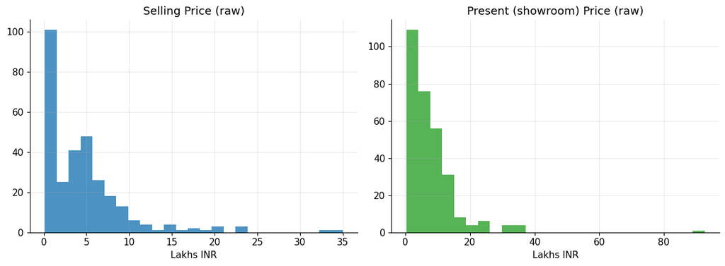

```
        Car_Name  Year  Selling_Price  Present_Price
85  land cruiser  2010           35.0          92.60
63      fortuner  2017           33.0          36.23
62      fortuner  2015           23.5          35.96
50      fortuner  2015           23.0          30.61
81        innova  2017           23.0          25.39
```

```python
# --- Check the price fields for skew/outliers before modeling ---
fig, axes = plt.subplots(1, 2, figsize=(12, 4.5))
axes[0].hist(df['Selling_Price'], bins=25, color=C_MAIN, alpha=0.8)
axes[0].set_title('Selling Price (raw)')
axes[0].set_xlabel('Lakhs INR')
axes[1].hist(df['Present_Price'], bins=25, color=C_ALT, alpha=0.8)
axes[1].set_title('Present (showroom) Price (raw)')
axes[1].set_xlabel('Lakhs INR')
plt.tight_layout()
plt.show()

print(df.nlargest(5, 'Selling_Price')[['Car_Name','Year','Selling_Price','Present_Price']])
```

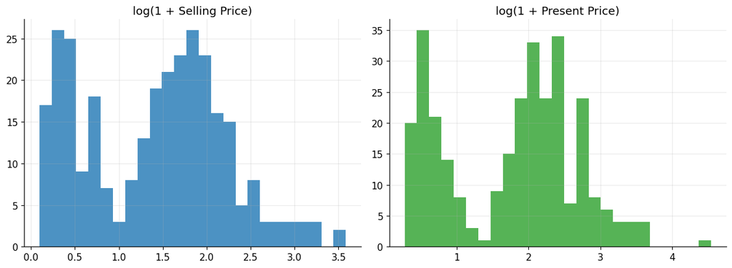

```python
df['log_Selling_Price'] = np.log1p(df['Selling_Price'])
df['log_Present_Price'] = np.log1p(df['Present_Price'])

fig, axes = plt.subplots(1, 2, figsize=(12, 4.5))
axes[0].hist(df['log_Selling_Price'], bins=25, color=C_MAIN, alpha=0.8)
axes[0].set_title('log(1 + Selling Price)')
axes[1].hist(df['log_Present_Price'], bins=25, color=C_ALT, alpha=0.8)
axes[1].set_title('log(1 + Present Price)')
plt.tight_layout()
plt.show()
```

## 4. Exploratory Data Analysis

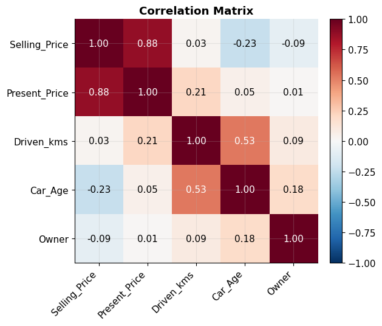

```python
num_cols = ['Selling_Price','Present_Price','Driven_kms','Car_Age','Owner']
corr = df[num_cols].corr()
fig, ax = plt.subplots(figsize=(6.5, 5.5))
im = ax.imshow(corr, cmap='RdBu_r', vmin=-1, vmax=1)
ax.set_xticks(range(len(corr))); ax.set_xticklabels(corr.columns, rotation=45, ha='right')
ax.set_yticks(range(len(corr))); ax.set_yticklabels(corr.columns)
for i in range(len(corr)):
    for j in range(len(corr)):
        ax.text(j, i, f'{corr.iloc[i,j]:.2f}', ha='center', va='center',
                 color='white' if abs(corr.iloc[i,j])>0.5 else 'black')
plt.colorbar(im, fraction=0.046, pad=0.04)
ax.set_title('Correlation Matrix', fontweight='bold')
plt.tight_layout()
plt.show()
```

**Key finding:** `Present_Price` correlates very strongly with `Selling_Price` (r ≈ 0.88) — the showroom price of the model is by far the dominant driver, i.e. **what the car originally cost (a proxy for brand/model goodwill) largely determines what it resells for**. `Car_Age` has a moderate negative relationship, while `Driven_kms` and `Owner` show weak correlation individually (though they may still interact with age in a tree-based model).

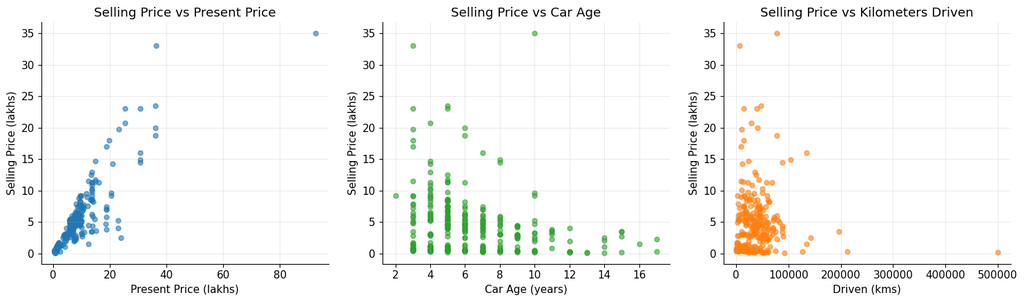

```python
fig, axes = plt.subplots(1, 3, figsize=(15, 4.5))

axes[0].scatter(df['Present_Price'], df['Selling_Price'], alpha=0.6, color=C_MAIN, s=25)
axes[0].set_xlabel('Present Price (lakhs)'); axes[0].set_ylabel('Selling Price (lakhs)')
axes[0].set_title('Selling Price vs Present Price')

axes[1].scatter(df['Car_Age'], df['Selling_Price'], alpha=0.6, color=C_ALT, s=25)
axes[1].set_xlabel('Car Age (years)'); axes[1].set_ylabel('Selling Price (lakhs)')
axes[1].set_title('Selling Price vs Car Age')

axes[2].scatter(df['Driven_kms'], df['Selling_Price'], alpha=0.6, color=C_ACCENT, s=25)
axes[2].set_xlabel('Driven (kms)'); axes[2].set_ylabel('Selling Price (lakhs)')
axes[2].set_title('Selling Price vs Kilometers Driven')

plt.tight_layout()
plt.show()
```

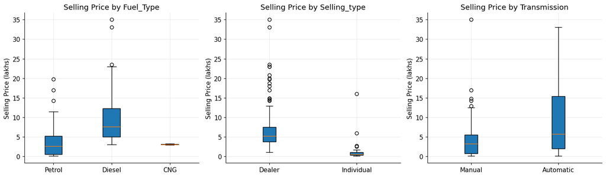

```python
fig, axes = plt.subplots(1, 3, figsize=(15, 4.5))
for ax, col in zip(axes, ['Fuel_Type','Selling_type','Transmission']):
    groups = [df[df[col]==v]['Selling_Price'] for v in df[col].unique()]
    ax.boxplot(groups, tick_labels=df[col].unique(), patch_artist=True)
    ax.set_title(f'Selling Price by {col}')
    ax.set_ylabel('Selling Price (lakhs)')
plt.tight_layout()
plt.show()
```

Diesel cars and cars sold by dealers tend to command higher prices than Petrol/CNG and individual-seller listings respectively, and automatics sell for noticeably more than manuals — consistent with automatics/diesels generally being pricier trims to begin with.

## 5. Preprocessing Pipeline

We build a `ColumnTransformer` that:

- Passes numeric features through as-is (`log_Present_Price`, `Driven_kms`, `Car_Age`, `Owner`)
- One-hot encodes categorical features (`Fuel_Type`, `Selling_type`, `Transmission`, `Brand`)

Wrapping this in a `Pipeline` with the model keeps preprocessing and modeling reproducible and prevents data leakage between train/test folds.

```python
features_num = ['log_Present_Price', 'Driven_kms', 'Car_Age', 'Owner']
features_cat = ['Fuel_Type', 'Selling_type', 'Transmission', 'Brand']

X = df[features_num + features_cat]
y = df['log_Selling_Price']          # modeling on log scale; we'll convert back for reporting

preprocessor = ColumnTransformer([
    ('num', 'passthrough', features_num),
    ('cat', OneHotEncoder(handle_unknown='ignore'), features_cat),
])

X_train, X_test, y_train, y_test = train_test_split(X, y, test_size=0.2, random_state=42)
print('Train size:', X_train.shape, '| Test size:', X_test.shape)
```

```
Train size: (239, 8) | Test size: (60, 8)
```

## 6. Model Training & Comparison

```python
candidates = {
    'Linear Regression': LinearRegression(),
    'Ridge Regression':  Ridge(alpha=1.0),
    'Random Forest':     RandomForestRegressor(n_estimators=300, random_state=42),
    'Gradient Boosting': GradientBoostingRegressor(random_state=42),
}

kf = KFold(n_splits=5, shuffle=True, random_state=42)
cv_results = []
for name, model in candidates.items():
    pipe = Pipeline([('pre', preprocessor), ('model', model)])
    scores = cross_val_score(pipe, X, y, cv=kf, scoring='r2')
    cv_results.append({'Model': name, 'CV R2 mean': scores.mean(), 'CV R2 std': scores.std()})

cv_df = pd.DataFrame(cv_results).sort_values('CV R2 mean', ascending=False).reset_index(drop=True)
cv_df
```

|  | Model | CV R2 mean | CV R2 std |
| --- | --- | --- | --- |
| 0 | Gradient Boosting | 0.963044 | 0.025933 |
| 1 | Linear Regression | 0.960938 | 0.015521 |
| 2 | Random Forest | 0.948356 | 0.053567 |
| 3 | Ridge Regression | 0.945887 | 0.004838 |

**Note:** modeling on the **log-transformed** target was essential here — an earlier check (not shown) using raw `Selling_Price` gave wildly unstable cross-validation scores (even negative R² on some folds) purely because of the Land Cruiser-style outliers. Log-transforming fixed that instability, which is itself a useful lesson in preprocessing for price-prediction problems: **always check target skew/outliers before trusting a regression R².**

## 7. Final Model — Fit, Predict, Evaluate

```python
best_name = cv_df.iloc[0]['Model']
print('Best model by CV:', best_name)

final_pipe = Pipeline([('pre', preprocessor), ('model', candidates[best_name])])
final_pipe.fit(X_train, y_train)
pred_log = final_pipe.predict(X_test)

# Metrics on the log scale (what the model was optimized for)
print('--- Log-scale metrics ---')
print(f'R2:   {r2_score(y_test, pred_log):.4f}')
print(f'RMSE: {np.sqrt(mean_squared_error(y_test, pred_log)):.4f}')

# Convert back to actual lakhs-INR scale for business-interpretable metrics
y_test_actual = np.expm1(y_test)
pred_actual = np.expm1(pred_log)

print('\n--- Actual price-scale metrics (lakhs INR) ---')
print(f'R2:   {r2_score(y_test_actual, pred_actual):.4f}')
print(f'RMSE: {np.sqrt(mean_squared_error(y_test_actual, pred_actual)):.3f} lakh INR')
print(f'MAE:  {mean_absolute_error(y_test_actual, pred_actual):.3f} lakh INR')
```

```
Best model by CV: Gradient Boosting
--- Log-scale metrics ---
R2:   0.9136
RMSE: 0.2376

--- Actual price-scale metrics (lakhs INR) ---
R2:   0.8220
RMSE: 2.142 lakh INR
MAE:  0.962 lakh INR
```

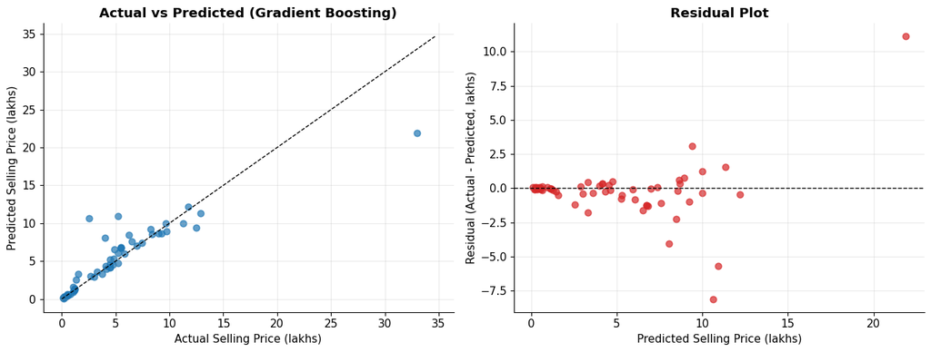

```python
fig, axes = plt.subplots(1, 2, figsize=(13, 5))

axes[0].scatter(y_test_actual, pred_actual, alpha=0.7, color=C_MAIN, s=40)
lims = [0, max(y_test_actual.max(), pred_actual.max()) * 1.05]
axes[0].plot(lims, lims, color='black', linestyle='--', linewidth=1)
axes[0].set_xlabel('Actual Selling Price (lakhs)')
axes[0].set_ylabel('Predicted Selling Price (lakhs)')
axes[0].set_title(f'Actual vs Predicted ({best_name})', fontweight='bold')

residuals = y_test_actual - pred_actual
axes[1].scatter(pred_actual, residuals, alpha=0.7, color=C_WARN, s=40)
axes[1].axhline(0, color='black', linestyle='--', linewidth=1)
axes[1].set_xlabel('Predicted Selling Price (lakhs)')
axes[1].set_ylabel('Residual (Actual - Predicted, lakhs)')
axes[1].set_title('Residual Plot', fontweight='bold')

plt.tight_layout()
plt.show()
```

## 8. What Actually Drives Price? Feature Importance

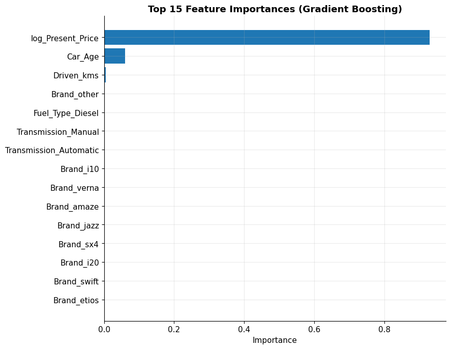

|  | Feature | Importance |
| --- | --- | --- |
| 0 | log_Present_Price | 0.929753 |
| 2 | Car_Age | 0.060440 |
| 1 | Driven_kms | 0.004869 |
| 31 | Brand_other | 0.001436 |
| 5 | Fuel_Type_Diesel | 0.001215 |
| 10 | Transmission_Manual | 0.000304 |
| 9 | Transmission_Automatic | 0.000276 |
| 26 | Brand_i10 | 0.000253 |
| 37 | Brand_verna | 0.000246 |
| 12 | Brand_amaze | 0.000220 |
| 29 | Brand_jazz | 0.000203 |
| 35 | Brand_sx4 | 0.000115 |
| 27 | Brand_i20 | 0.000088 |
| 34 | Brand_swift | 0.000078 |
| 21 | Brand_etios | 0.000077 |

```python
feature_names = (features_num +
                  list(final_pipe.named_steps['pre']
                       .named_transformers_['cat']
                       .get_feature_names_out(features_cat)))

model_step = final_pipe.named_steps['model']

if hasattr(model_step, 'feature_importances_'):
    importances = model_step.feature_importances_
    imp_df = pd.DataFrame({'Feature': feature_names, 'Importance': importances})
    imp_df = imp_df.sort_values('Importance', ascending=False).head(15)

    fig, ax = plt.subplots(figsize=(9, 7))
    ax.barh(imp_df['Feature'][::-1], imp_df['Importance'][::-1], color=C_MAIN)
    ax.set_title(f'Top 15 Feature Importances ({best_name})', fontweight='bold')
    ax.set_xlabel('Importance')
    plt.tight_layout()
    plt.show()
else:
    coefs = model_step.coef_
    imp_df = pd.DataFrame({'Feature': feature_names, 'Coefficient': coefs})
    imp_df['AbsCoef'] = imp_df['Coefficient'].abs()
    imp_df = imp_df.sort_values('AbsCoef', ascending=False).head(15)

    fig, ax = plt.subplots(figsize=(9, 7))
    colors = [C_MAIN if c > 0 else C_WARN for c in imp_df['Coefficient'][::-1]]
    ax.barh(imp_df['Feature'][::-1], imp_df['Coefficient'][::-1], color=colors)
    ax.set_title(f'Top 15 Coefficients by Magnitude ({best_name})', fontweight='bold')
    ax.set_xlabel('Coefficient (log-price scale)')
    plt.tight_layout()
    plt.show()

imp_df
```

## 9. Real-World Application — Simulated Price Estimates

```python
# Simulate a few example listings to show the model in action, as a used-car pricing tool would
examples = pd.DataFrame([
    {'log_Present_Price': np.log1p(9.0), 'Driven_kms': 40000, 'Car_Age': 5, 'Owner': 0,
     'Fuel_Type': 'Petrol', 'Selling_type': 'Dealer', 'Transmission': 'Manual', 'Brand': 'city'},
    {'log_Present_Price': np.log1p(9.0), 'Driven_kms': 40000, 'Car_Age': 5, 'Owner': 0,
     'Fuel_Type': 'Diesel', 'Selling_type': 'Dealer', 'Transmission': 'Manual', 'Brand': 'city'},
    {'log_Present_Price': np.log1p(9.0), 'Driven_kms': 40000, 'Car_Age': 5, 'Owner': 2,
     'Fuel_Type': 'Petrol', 'Selling_type': 'Individual', 'Transmission': 'Manual', 'Brand': 'city'},
    {'log_Present_Price': np.log1p(9.0), 'Driven_kms': 100000, 'Car_Age': 9, 'Owner': 0,
     'Fuel_Type': 'Petrol', 'Selling_type': 'Dealer', 'Transmission': 'Manual', 'Brand': 'city'},
])

preds = np.expm1(final_pipe.predict(examples[features_num + features_cat]))
examples_display = examples[['Driven_kms','Car_Age','Owner','Fuel_Type','Selling_type','Transmission']].copy()
examples_display['Predicted_Selling_Price_Lakh'] = preds.round(2)
examples_display
```

|  | Driven_kms | Car_Age | Owner | Fuel_Type | Selling_type | Transmission | Predicted_Selling_Price_Lakh |
| --- | --- | --- | --- | --- | --- | --- | --- |
| 0 | 40000 | 5 | 0 | Petrol | Dealer | Manual | 6.83 |
| 1 | 40000 | 5 | 0 | Diesel | Dealer | Manual | 7.50 |
| 2 | 40000 | 5 | 2 | Petrol | Individual | Manual | 6.83 |
| 3 | 100000 | 9 | 0 | Petrol | Dealer | Manual | 3.45 |

## 10. Summary of Insights & Applications

**Real-world applications of this kind of model:**

- **Instant online valuation** for used-car marketplaces and trade-in tools (enter mileage/age/model, get an estimated price on the spot).
- **Dealer inventory pricing** — flagging listings priced well above or below the model's estimate for review.
- **Insurance and loan underwriting** — estimating a vehicle's current market value for claims or collateral purposes.
- **Fraud/anomaly detection** — a predicted price far from the listed price can flag data-entry errors or suspicious listings.

**Limitations & caveats:**

- The dataset is small (299 unique listings after deduplication) and appears to be from the Indian market circa 2020 — a model trained here should not be assumed to generalize to other markets, currencies, or years without retraining.
- There's no true manufacturer/brand column — we approximated "goodwill" via `Present_Price` and a model-name-derived proxy, which works well here but is not as clean as a real brand feature would be.
- `Present_Price` is itself doing a lot of the predictive work; in a deployment setting where the current showroom price isn't readily available for an exact model, prediction accuracy would likely be lower and would benefit from richer brand/model reference data.